# Visualizing the Weapon’s Attack Range

Visualizing the *Weapon2D*’s fire range is important to help players make informed decisions. They need to know the best place to build towers and optimize their strategies.

[figure not shown]

[figure not shown]

We’ll use a *Tween* to make the visualization more appealing. It will interpolate the *RangePreview*’s scale to shrink and grow it. This provides a better user experience than showing or hiding a texture on the screen with no animation.

Add a *Tween* as a child of the *RangePreview* and save the scene as `res://Objects/Weapon2D/RangePreview/RangePreview.tscn`.

Attach a new script to the *RangePreview* and save it together with the scene.

We start by exporting two variables to represent the final radius of the *RangePreview* in pixels and the duration of the tween animation.

```
extends Sprite

export var radius := 100.0
export var tween_duration := 0.5

onready var _tween := $Tween
```

Let’s look at how to make the *RangePreview* appear and disappear.

The *RangePreview* should grow to match its `radius`. We need to find the `ratio` between the `radius` and the `texture` size to find the proper scale.

Note that we’ve designed the *range-preview.svg* image to be `100` wide to make the math easier.

We can access the size of a *Texture* using the `get_size()` method. We only need to know its width to calculate the `ratio` since we are working with the radius.

We can use the `ratio` to create a *Vector2* that represents the `final_scale`. We need to multiply the `ratio` by `2` to get the proper diameter.

```
func appear() -> void:
  # Calculate the ratio between the radius and the texture's width
    var ratio = radius / texture.get_width()

  # Multiply the radius by 2 to match the actual final scale of the range's circle
    var final_scale = Vector2(ratio, ratio) * 2
```

Calling `_stop_all()` on the `_tween` will “pause” the interpolation and keep the values as they are. If the player quickly shows or hides the *RangePreview*, the new animation will start from the paused values. This gives a smoother animation between states.

We can also interpolate the *RangePreview*’s `modulate` from transparent to opaque. This will make it look like it’s a hologram.

With the interpolations in place, we need to call the `_tween.start()`. Otherwise, they will never happen.

```
    _tween.stop_all()

    _tween.interpolate_property(
        self, "scale", scale, final_scale, tween_duration, Tween.TRANS_QUINT, Tween.EASE_OUT
    )
    _tween.interpolate_property(
        self, "modulate", modulate, Color(1, 1, 1, 1), tween_duration, Tween.TRANS_LINEAR
    )
    _tween.start()
```

We do the opposite to make the *RangePreview* disappear. Let’s interpolate the `scale` to `Vector2.ZERO`. Since this is always our target scale we don’t need to calculate anything.

We interpolate the `modulate` to transparent white and increase the time it takes because it’d look strange if the *RangePreview* turns transparent before its `scale` tween finishes.

```
func disappear() -> void:
    if _tween.is_active():
        _tween.stop_all()

    _tween.interpolate_property(
        self, "scale", scale, Vector2.ZERO, tween_duration, Tween.TRANS_BACK, Tween.EASE_IN
    )
    _tween.interpolate_property(
        self, "modulate", modulate, Color(1, 1, 1, 0), tween_duration * 2.0)
    _tween.start()
```

Before we move on, set the alpha of *Visibility > Modulate* to `0` so it’s not visible while we work on other scenes.

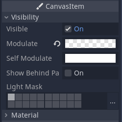

## Shooting bullets

Let’s move back to the *Weapon2D* scene and add an instance of the *RangePreview*. We also create an interface to show or hide it.

In the *Weapon2D* script, create a reference to the *RangePreview*. Then, create two methods. One to `show_range()` and other to `hide_range()`.

We can display the *Weapon2D*’s range as soon as it appears in the scene for the player’s convenience.

```
class_name Weapon2D
extends Node2D

# ...

onready var _range_preview := $RangePreview


func _ready() -> void:
    set_fire_range(fire_range)
    show_range()


func show_range() -> void:
    _range_preview.radius = fire_range
    _range_preview.appear()


func hide_range() -> void:
    _range_preview.disappear()

# ...
```

Finally, drag the *Bullet* scene we created to the *Weapon2D*’s *Bullet Scene* slot in the *Inspector*.

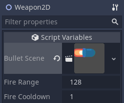

## Testing the weapon

To test the *Weapon2D*, call the `shoot_at()` method while holding the left-mouse button below our cooldown check in the `_physics_process()` callback. We pass the mouse `global_position` as `target_position`.

Don’t forget to remove this snippet after testing.

```
func _physics_process(_delta: float) -> void:
    if not _cooldown_timer.is_stopped():
        return

    # Remove this snippet after testing
    if Input.is_mouse_button_pressed(BUTTON_LEFT):
        shoot_at(get_global_mouse_position())
```

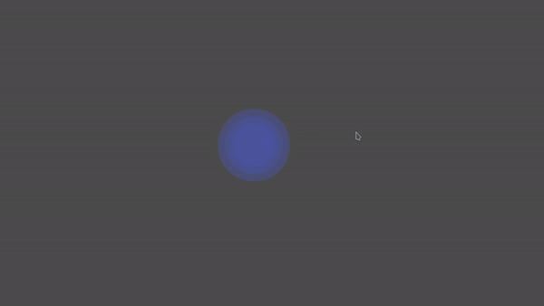

You can test the *RangePreview* by changing the *Weapon2D > Fire Range* in the *Inspector*.

In the next lesson, we’ll create the towers and attach weapons to them.

## Code reference

`RangePreview.gd`

```
extends Sprite

export var radius := 100.0
export var tween_duration := 0.5

onready var _tween := $Tween


func appear() -> void:
    var ratio = radius / texture.get_width()
    var final_scale = Vector2(ratio, ratio) * 2.0

    _tween.stop_all()

    _tween.interpolate_property(
        self, "scale", scale, final_scale, tween_duration, Tween.TRANS_QUINT, Tween.EASE_OUT
    )
    _tween.interpolate_property(
        self, "modulate", modulate, Color(1, 1, 1, 1), tween_duration)
    _tween.start()


func disappear() -> void:
    if _tween.is_active():
        _tween.stop_all()

    _tween.interpolate_property(
        self, "scale", scale, Vector2.ZERO, tween_duration, Tween.TRANS_BACK, Tween.EASE_IN
    )
    _tween.interpolate_property(
        self, "modulate", modulate, Color(1, 1, 1, 0), tween_duration * 2.0)
    _tween.start()
```

`Weapon.gd`

```
class_name Weapon2D
extends Node2D

export var bullet_scene: PackedScene
export var fire_range := 128.0 setget set_fire_range
export var fire_cooldown := 1.0

onready var _bullet_spawn_position := $BulletSpawnPosition2D
onready var _cooldown_timer := $CooldownTimer
onready var _range_area := $RangeArea2D
onready var _animation_player := $AnimationPlayer
onready var _range_shape: CircleShape2D = $RangeArea2D/CollisionShape2D.shape
onready var _range_preview := $RangePreview


func _ready() -> void:
    set_fire_range(fire_range)
    show_range()


func _physics_process(_delta: float) -> void:
    if not _cooldown_timer.is_stopped():
        return

    var targets: Array = _range_area.get_overlapping_areas()
    if targets.empty():
        return

    var target: Node2D = targets[0]
    shoot_at(target.global_position)


func set_fire_range(new_range: float) -> void:
    fire_range = new_range
    if not is_inside_tree():
        yield(self, "ready")
    _range_shape.radius = fire_range


func shoot_at(target_position: Vector2) -> void:
    look_at(target_position)
    _animation_player.play("shoot")

    var bullet = bullet_scene.instance()
    add_child(bullet)
    bullet.global_position = _bullet_spawn_position.global_position
    bullet.fly_to(target_position)

    _cooldown_timer.start(fire_cooldown)

func show_range() -> void:
    _range_preview.radius = fire_range
    _range_preview.appear()


func hide_range() -> void:
    _range_preview.disappear()
```